# Supporting Information 2

02 June, 2025

# Background

This study aims to explore the relationship between environmental variables and the population dynamics of krill (*Euphausia superba*), incorporating spatial complexity and biological components such as length data from fishery monitoring. By using lineal models, we assess how environmental factors influence krill recruit across different strata, considering both spatial and temporal scales. By identifying correlations between environmental variables and population or fishery indicators, this study also aims to establish a time series of key environmental factors for potential integration into stock assessment models. This approach follows similar methodologies to Wang et al. (2021), but applied to a longer fishery time series. Our main research question concerns the effects of distinct physical and oceanographic factors in the Southern Ocean on krill population structure. Specifically, we examine whether environmental variability drives changes in krill recruit within the fishery, influencing population dynamics across spatial and temporal dimensions.

# Methodology

## Spatial heterogeneity

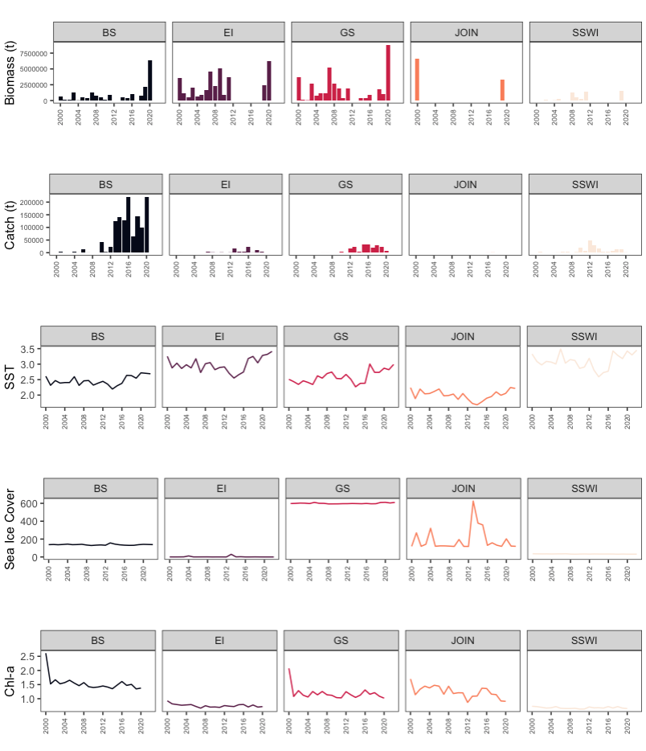

Figure 1: Spatial heterogeneity of krill biomass, catch, and environmental variables across management units in the Antarctic Peninsula (BS, EI, GS, JOIN, SSWI)

## Length composition data as indicator of recruitment

This analysis was made follow Perry (2020) method.

Next, the *PROPLOG* values are standardized to fall within a specific range, typically between -1 and 1. This standardization process is achieved by applying the following equation:

$$\text{PROPLOG2} = \frac{\text{PROPLOG} - \text{min}(\text{PROPLOG})}{\text{max}(\text{PROPLOG}) - \text{min}(\text{PROPLOG})} \times (b - a) + a$$

In this equation:

- **PROPLOG** is the logarithm of the proportion of juvenile krill individuals.
- **PROPLOG2** is the standardized recruitment index, scaled between -1 and 1.
- **min()** and **max()** refer to the minimum and maximum values of **PROPLOG** across all observations.
- **a** and **b** are the lower and upper bounds of the desired range for standardization, which are set to -1 and 1, respectively.

Finally, the standardized index is categorized into two groups based on its value: “positive” for values greater than or equal to 0, and “negative” for values below 0. This categorization allows for further analysis of recruitment trends and patterns within the krill population over time.

This methodology ensures that the recruitment index is both consistent and comparable across different years and groups.

```r
indice_reclutamiento <- sf5 %>%
    filter(length_total_cm < 3.6) %>%
    group_by(Year, ID) %>%
    summarise(PROP = n()/nrow(sf5), .groups = "drop") %>%
    mutate(PROPLOG = log(PROP))

# Paso 2: Estandarizar el índice logarítmico entre -1
# y 1
a <- -1
b <- 1
min_x <- min(indice_reclutamiento$PROPLOG, na.rm = TRUE)
max_x <- max(indice_reclutamiento$PROPLOG, na.rm = TRUE)

indice_reclutamiento <- indice_reclutamiento %>%
    mutate(PROPLOG2 = ((PROPLOG - min_x)/(max_x - min_x)) *
        (b - a) + a)

indice_reclutamiento <- indice_reclutamiento %>%
    mutate(color_index = ifelse(PROPLOG2 >= 0, "positive",
        "negative"))
```

Figure 2 show recruit index by strata.

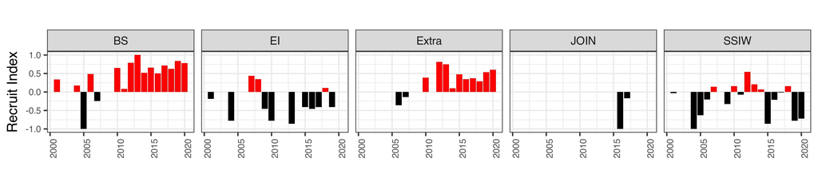

Figure 2: Krill Recruit index by strata

```r
ggplot(indice_reclutamiento %>%
    filter(ID != "Outer"), aes(x = Year, y = PROPLOG2, fill = color_index)) +
    geom_col(position = "dodge") + facet_wrap(~ID, ncol = 5) +
    scale_fill_manual(values = c(positive = "red", negative = "black")) +
    labs(title = "", y = "Recruit Index", x = "", fill = "") +
    theme_bw() + theme(axis.text.x = element_text(angle = 90,
    hjust = 1), axis.text = element_text(size = 7), legend.position = "none")
```

```r
data_large2 <- data_large2 %>%
    rename(Year = ANO)

# Paso 2: Unir por ID y Year
data_completa <- left_join(data_large2, indice_reclutamiento,
    by = c("ID", "Year"))
# saveRDS(data_completa,
# 'data/Data_recruit_env.Rdata')
```

## Test Correlation

The Pearson test are statistical methods used to assess the correlation between two variables. The Pearson test evaluates the linear correlation between two continuous variables. In the case of the Pearson test, the degree of association between two continuous variables is measured through a correlation coefficient that varies between -1 and 1. A value of 1 indicates a perfectly positive correlation, a value of -1 indicates a perfectly negative correlation, and a value of 0 indicates no correlation between the two variables (McCulloch & Searle, 2001).

- Pearson Product-Moment Coefficient

This is the most widely used correlation analysis formula, which measures the strength of the ‘linear’ relationships between the raw data from both variables, rather than their ranks. This is an dimensionless coefficient, meaning that there are no data-related boundaries to be considered when conducting analyses with this formula, which is a reason why this coefficient is the first formula researchers try.

```r
data_corr <- data_completa %>%
    dplyr::select(-ID, -color_index) %>%
    dplyr::mutate(across(where(is.character), as.numeric)) %>%
    cor(method = "pearson", use = "complete.obs")
```

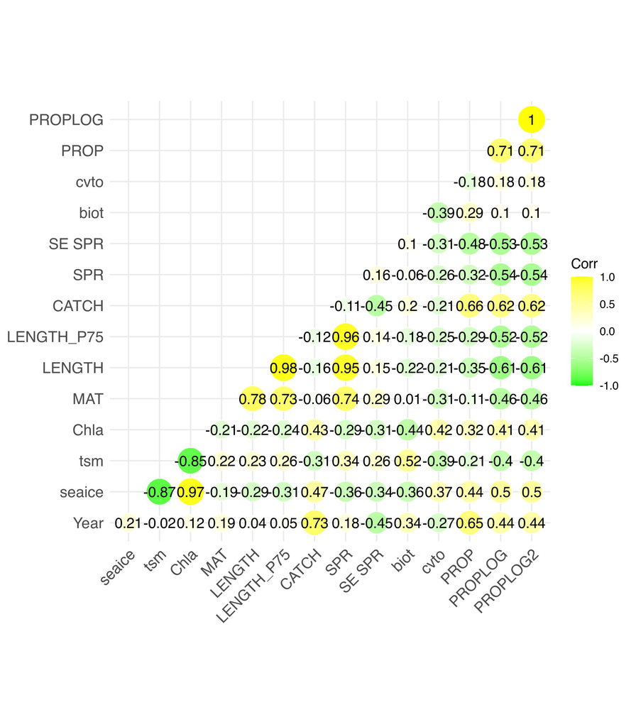

Figure 3: Coorrelation plot to different variables.

```r
ggcorrplot(data_corr, method = "circle", type = "lower",
    colors = c("green", "white", "yellow"), lab = TRUE,
    outline.col = "white", ggtheme = theme_minimal())
```

The correlation matrix provides valuable insights into the relationships among the variables (Figure 3):

This plot is a correlation matrix that visualizes the pairwise relationships between variables using both color intensity and numerical values. Yellow indicates strong positive correlations (close to +1), green indicates strong negative correlations (close to –1), and lighter colors represent weaker correlations (closer to 0). The size of each circle is also proportional to the strength of the correlation.

## Variable Distribution

To explore the distribution of numerical variables in our dataset, we conducted a histogram analysis (Figure 4. First, we excluded non-numeric variables (`ID`, `Year`, `SE SPR`, and `cvto`) to focus on the remaining quantitative data. The results from this exploratory analysis provided essential insights into the characteristics of our dataset, helping to guide subsequent modeling and statistical analyses.

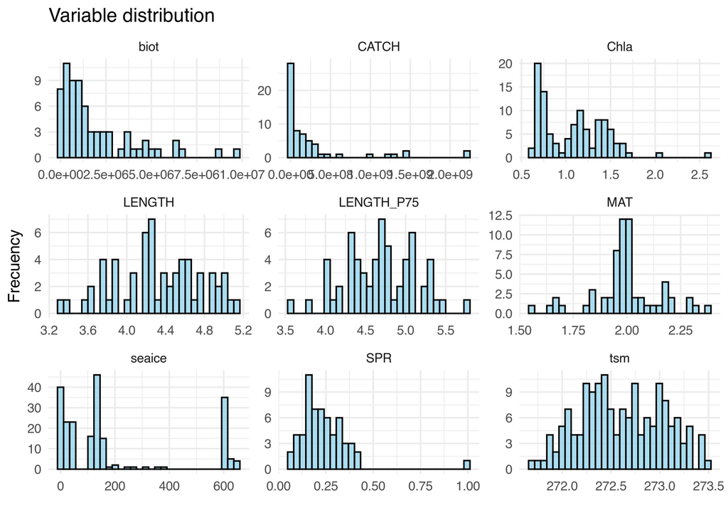

Figure 4: Distribution of numerical variables to test assumtion of regresion models

```r
data_filtered2 <- data_large2 %>%
    dplyr::select(-ID, -Year, -`SE SPR`, -cvto) %>%
    pivot_longer(cols = everything(), names_to = "Variable",
        values_to = "Valor")

ggplot(data_filtered2, aes(x = Valor)) + geom_histogram(bins = 30,
    fill = "skyblue", color = "black", alpha = 0.7) + facet_wrap(~Variable,
    scales = "free") + theme_minimal() + labs(title = "Variable distribution",
    x = "", y = "Frecuency")
```

## Models

The analysis of the correlation between the recruitment index (PROPLOG2) and environmental variables will be approached through a series of regression models designed to examine the impact of various environmental factors on the recruitment process of krill. These models progressively include more explanatory variables, allowing us to evaluate the relative contribution of each environmental factor, as well as potential interactions between them, on the recruitment index. Each model represents a different level of complexity and addresses distinct aspects of the potential relationship between recruitment and environmental conditions.

The second model (Mod 2) introduces *Chla* (chlorophyll a concentration) as an additional explanatory variable. This model will allow for the evaluation of how changes in primary production, represented by chlorophyll a, may influence recruitment. The inclusion of chlorophyll a will help determine whether biological productivity, as reflected by phytoplankton concentrations, plays a role in shaping recruitment dynamics.

Finally, the model labeled “Mod 5 Lag” considers a lag effect for both TSM and Chla, where the values of these variables from the previous time point are included. This lag effect will help us assess whether past environmental conditions influence current recruitment levels, reflecting the potential delayed response of the ecosystem to changes in these variables.

By comparing the results of these models, we can systematically evaluate the contribution of each environmental factor and their interactions to the recruitment index. The inclusion of lags in the final model will provide insights into the temporal dynamics of the recruitment process, shedding light on how past environmental conditions might influence current recruitment patterns. This methodology allows for a comprehensive assessment of the factors affecting krill recruitment and their potential implications for the population dynamics of this important marine species.

$$\text{Mod 1:} \quad PROPLOG2_{i} = \beta_0 + \beta_1 ID_{i} + \epsilon_i$$

$$\text{Mod 2:} \quad PROPLOG2_{i} = \beta_0 + \beta_1 ID_{i} + \beta_2 Chla_{i} + \epsilon_i$$

$$\text{Mod 3:} \quad PROPLOG2_{i} = \beta_0 + \beta_1 ID_{i} + \beta_2 Chla_{i} + \beta_3 TSM_{i} + \epsilon_i$$

$$\text{Mod 4:} \quad PROPLOG2_{i} = \beta_0 + \beta_1 ID_{i} + \beta_2 Chla_{i} + \beta_3 TSM_{i} + \beta_4 seaice_{i} + \epsilon_i$$

$$\text{Mod 5:} \quad PROPLOG2_{i} = \beta_0 + \beta_1 ID_{i} + \beta_2 seaice_{i} + \beta_3 TSM_{i} + \beta_4 Chla_{i} + \beta_5 (TSM \times Chla)_{i} + \epsilon_i$$

$$\text{Mod 5 Lag:} \quad PROPLOG2_{i} = \beta_0 + \beta_1 ID_{i} + \beta_2 seaice_{i} + \beta_3 TSM_{i-1} + \beta_4 Chla_{i-1} + \beta_5 (TSM_{i-1} \times Chla_{i-1})_{i} + \epsilon_i$$

This represents each model in mathematical terms, where $\beta$ are the coefficients and $\epsilon_i$ is the error term.

```r
# Prepara los datos Base filtrada y normalizada
data_modelo <- data_completa %>%
    drop_na(PROPLOG2, Chla, tsm, seaice) %>%
    filter(Year > 1999) %>%
    mutate(tsm = scale(tsm), Chla = scale(Chla), seaice = scale(seaice))

# Modelo 1: Solo ID
mod1_R <- glm(PROPLOG2 ~ ID + Year, data = data_modelo)

# Modelo 2: ID + Chla
mod2_R <- glm(PROPLOG2 ~ ID + Year + Chla, data = data_modelo)

# Modelo 3: ID + Chla + tsm
mod3_R <- glm(PROPLOG2 ~ ID + Year + Chla + tsm, data = data_modelo)

# Modelo 4: ID + Chla + tsm + seaice
mod4_R <- glm(PROPLOG2 ~ ID + Year + Chla + tsm + seaice,
    data = data_modelo)

# Modelo 5: ID + seaice + interacción tsm * Chla
mod5_R <- glm(PROPLOG2 ~ ID + Year + seaice + tsm * Chla,
    data = data_modelo)

# Crear variables con retardo temporal (lag 1 año)
data_lag <- data_modelo %>%
    arrange(ID, Year) %>%
    group_by(ID) %>%
    mutate(tsm_lag = lag(tsm, 1), Chla_lag = lag(Chla, 1),
        seaice_lag = lag(seaice, 1)) %>%
    ungroup() %>%
    drop_na(tsm_lag, Chla_lag, seaice_lag)

# Modelo 5 con retardo
mod5_R_lag <- glm(PROPLOG2 ~ ID + Year + seaice_lag + tsm_lag *
    Chla_lag, data = data_lag)
```

# Results

```r
model_comparison <- compare_performance(mod1_R, mod2_R,
    mod3_R, mod4_R, mod5_R, mod5_R_lag, rank = TRUE, verbose = FALSE)

model_comparison %>%
    kable(format = "html", digits = 3, align = "c", caption = "Model Performance Comparison") %>%
    kable_styling(full_width = TRUE, bootstrap_options = c("striped",
        "hover", "condensed", "responsive")) %>%
    scroll_box(width = "100%", height = "400px")
```

Table 1: Model Performance Comparison

| Name | Model | R2 | RMSE | Sigma | AIC_wt | AICc_wt | BIC_wt | Performance_Score |
| --- | --- | --- | --- | --- | --- | --- | --- | --- |
| mod2_R | glm | 0.594 | 0.383 | 0.419 | 0.405 | 0.600 | 0.574 | 0.891 |
| mod3_R | glm | 0.610 | 0.375 | 0.419 | 0.279 | 0.201 | 0.196 | 0.659 |
| mod5_R | glm | 0.635 | 0.363 | 0.423 | 0.102 | 0.010 | 0.018 | 0.533 |
| mod4_R | glm | 0.619 | 0.370 | 0.423 | 0.145 | 0.043 | 0.051 | 0.529 |
| mod1_R | glm | 0.504 | 0.423 | 0.454 | 0.055 | 0.145 | 0.157 | 0.180 |
| mod5_R_lag | glm | 0.528 | 0.407 | 0.486 | 0.015 | 0.001 | 0.004 | 0.074 |

The Figure 5 show graphically the performance in the models.

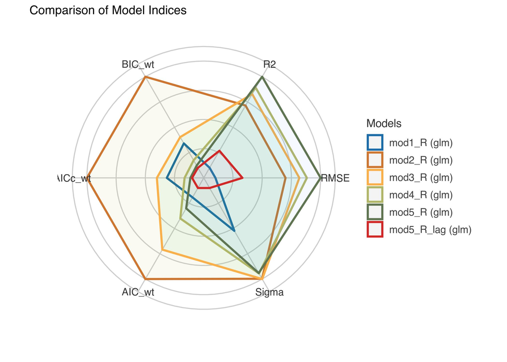

Figure 5: Comparision the performance and quality of several models

```r
plot(compare_performance(mod1_R, mod2_R, mod3_R, mod4_R,
    mod5_R, mod5_R_lag, rank = TRUE, verbose = FALSE))
```

```r
tabla_coef <- broom::tidy(mod2_R)

# Redondear columnas numéricas
tabla_coef <- tabla_coef %>%
    mutate(across(where(is.numeric), round, 4))

# Crear tabla HTML
tabla_coef %>%
    kable(format = "html", escape = FALSE, caption = "Summary of GLM model for PROPLOG2",
        col.names = c("Term", "Estimate", "Std. Error",
            "t value", "Pr(>|t|)")) %>%
    kable_styling(full_width = FALSE, bootstrap_options = c("striped",
        "hover", "condensed"))
```

Table 2: Summary of GLM model for PROPLOG2

| Term | Estimate | Std. Error | t value | Pr(>\|t\|) |
| --- | --- | --- | --- | --- |
| (Intercept) | -26.0863 | 30.8799 | -0.8448 | 0.4063 |
| IDEI | -2.6355 | 0.8193 | -3.2167 | 0.0036 |
| IDJOIN | -1.6326 | 0.3821 | -4.2721 | 0.0002 |
| Year | 0.0136 | 0.0153 | 0.8881 | 0.3830 |
| Chla | -0.9401 | 0.3997 | -2.3521 | 0.0268 |

The results from the generalized linear model (GLM) with the formula `PROPLOG2 ~ ID + Year + Chla` are as follows:

The coefficients are as follows:

- **(Intercept)**: -26.08628, p = 0.406254  
  The intercept is negative (-26.08628) but not statistically significant (p = 0.406), indicating that it does not have a meaningful effect on the response variable.
- **IDEI (ID)**: -2.63547, p = 0.003567  
  The coefficient for `IDEI` is negative (-2.63547) and statistically significant (p = 0.003567), suggesting that an increase in `IDEI` leads to a decrease in `PROPLOG2`.
- **IDJOIN (ID)**: -1.63256, p = 0.000246  
  The coefficient for `IDJOIN` is also negative (-1.63256) and highly statistically significant (p = 0.000246). This indicates that an increase in `IDJOIN` is associated with a decrease in `PROPLOG2`.
- **Year (Año)**: 0.01358, p = 0.382954  
  The coefficient for `Year` is positive (0.01358), but it is not statistically significant (p = 0.383), suggesting that `Year` does not have a meaningful effect on `PROPLOG2`.
- **Chla (Chlorophyll a)**: -0.94014, p = 0.026849  
  The coefficient for `Chla` is negative (-0.94014) and statistically significant (p = 0.026849), indicating that an increase in `Chla` leads to a decrease in `PROPLOG2`.

Regarding the model fit:

- The **null deviance** is 10.8104, which represents the deviance of a model with no predictors.
- The **residual deviance** is 4.3936, which is the deviance of the fitted model.
- The **AIC (Akaike Information Criterion)** is 39.505, which helps to compare this model to others (lower values indicate a better fit).

The model uses two iterations of Fisher scoring for optimization.

In summary, the model suggests that `IDEI`, `IDJOIN`, and `Chla` have significant effects on `PROPLOG2`, while `Year` does not. The residual deviance and AIC indicate a reasonable fit, but the model could potentially be improved by including more predictors or transformations.

```r
data_large3 <- data_completa %>%
    arrange(ID, Year) %>%
    group_by(ID) %>%
    mutate(SPR_lag = lag(SPR)) %>%
    ungroup()
```

Figure 6 show negative relation between recruit index and Chl-a.

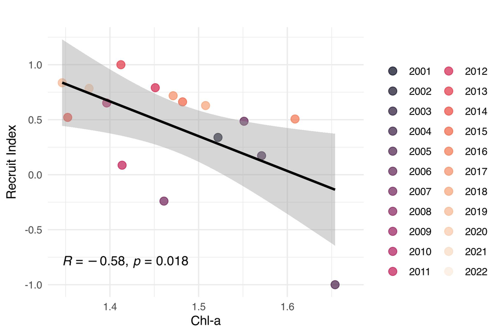

Figure 6: Relationship between mean annual chlorophyll-a concentration (Chl-a) and the standardized krill recruit index across years (2001-2022). Each point represents a year and is color-coded accordingly. The black line represents a linear regression fit with a 95% confidence interval (shaded area). A significant negative correlation was found between Chl-a and the recruit index (*R* = - 0.58, *p* = 0.018)

```r
ggplot(data_large3 %>%
    filter(Year > 2000, ID == "BS"), aes(x = Chla, y = PROPLOG2)) +
    geom_point(size = 3, alpha = 0.7, aes(color = as.factor(Year))) +
    geom_smooth(method = "lm", se = TRUE, color = "black") +
    stat_cor(method = "pearson", label.y.npc = "bottom") +
    # facet_wrap(~ID, scales = 'free', ncol=5) +
theme_minimal() + scale_color_viridis_d(option = "F", name = "") +
    labs(title = "", x = "Chl-a", y = "Recruit Index", color = "Año")
```

# Conclusion

The results of Model 2, which includes `ID`, `Year`, and `Chla` as predictors for `PROPLOG2`, reveal several significant findings. The negative coefficient for `IDEI` indicates that as `IDEI` increases, the response variable `PROPLOG2` decreases, with a statistically significant p-value (0.003567). Similarly, the negative coefficient for `IDJOIN` suggests that an increase in `IDJOIN` also leads to a decrease in `PROPLOG2`, and this relationship is highly significant (p = 0.000246).

While the `Year` variable shows a positive but non-significant effect (p = 0.382954), suggesting that the year does not have a notable impact on `PROPLOG2`, the `Chla` variable exhibits a significant negative relationship with the response variable (p = 0.026849). This suggests that higher levels of chlorophyll-a (`Chla`) are associated with lower values of `PROPLOG2`.

The model’s AIC value (39.505) and residual deviance (4.3936) suggest a reasonable fit, with the predictors included contributing to explaining the variability in the response variable. However, given that `Year` is not statistically significant, further investigation could explore alternative variables or transformations to improve the model’s explanatory power.

Overall, these findings demonstrate that krill population structure is shaped not only by fishing pressure but also by environmental conditions. By incorporating these environmental components into stock assessment models, we enhance our understanding of krill population dynamics in the Antarctic Peninsula, particularly in Subarea 48.1, and improve the ecological realism of predictive models such as LBSPR.

# Code Repository

The data, codes and other documents of this analysis can be found in the following link [Environment and Krill Recruit relation](https://github.com/MauroMardones/Krill_recruit_env)

# References

McCulloch, C. E., & Searle, S. R. (2001). *Generalized, Linear, and Mixed Models* (Vol. 45, pp. 99–99). https://doi.org/10.1198/tech.2003.s13

Perry, F. (2020). *Antarctic krill recruitment in the south-west Atlantic sector of the Southern Ocean* (p. 310) [PhD thesis]. UNIVERSITY OF SOUTHAMPTON.

Wang, R., Song, P., Li, Y., & Lin, L. (2021). An Integrated, Size-Structured Stock Assessment of Antarctic Krill, Euphausia superba. *Frontiers in Marine Science*, *8*(November), 1–15. https://doi.org/10.3389/fmars.2021.710544